# Homework#1

Samuel Condori

2024-01-26

## Problem 1

This question refers to Example 1 from the lecture, where we examined in detail the ’inflation‘ variable. Reproduce the example by doing the following:

```r
canada80s <- read.csv("C:/Users/samal/OneDrive/Desktop/Time Series Class/Datasets/CanadaEcon80s.csv", header = TRUE)
suppressPackageStartupMessages(library(dplyr))
```

1. Create a lagged ’unemployment‘ variable, lag 1 is sufficient.

```r
canada80s<-canada80s %>%
  mutate(lag1_unemp = ifelse(c(0, diff(t)) == 1, lag(unemp, n = 1,
                                                   default = NA), NA)) %>%
  as.data.frame()
```

2. Check whether a lag 1 effect of y on itself is present.

```r
unemployment<-canada80s$unemp
Lagged_unemployement<-canada80s$lag1_unemp
#Check correlation first
cor(unemployment,Lagged_unemployement, use="pairwise.complete.obs")
```

```
## [1] 0.9883463
```

```r
unemp_reg1<-lm(unemployment~Lagged_unemployement)
summary(unemp_reg1)
```

```
##
## Call:
## lm(formula = unemployment ~ Lagged_unemployement)
##
## Residuals:
##      Min       1Q   Median       3Q      Max
## -0.56235 -0.16811 -0.02683  0.12690  0.73304
##
## Coefficients:
##                      Estimate Std. Error t value Pr(>|t|)
## (Intercept)           0.14196    0.14139   1.004    0.318
## Lagged_unemployement  0.98465    0.01473  66.847   <2e-16 ***
## ---
## Signif. codes:  0 '***' 0.001 '**' 0.01 '*' 0.05 '.' 0.1 ' ' 1
##
## Residual standard error: 0.2216 on 106 degrees of freedom
##   (1 observation deleted due to missingness)
## Multiple R-squared:  0.9768, Adjusted R-squared:  0.9766
## F-statistic:  4469 on 1 and 106 DF,  p-value: < 2.2e-16
```

3. Explain your results, describing the relationship of the variable with itself and the model characteristics.

The regression shows that the variable unemplyment can explain by itself’s previous data. The R-squared is 97%, while the p-value is < 2.2e-16, which means that the previous tendency of unemployment can explain the current unemployment.

## Problem 2

2. This question refers to Example 2 from the lecture, where we examined in detail the topic of detrending.

```r
milk_data <- read.csv("C:/Users/samal/OneDrive/Desktop/Time Series Class/Datasets/CADairyProduction.csv", header=TRUE)
```

1. For this question, detrend the milk data for a quadratic trend.

```r
Milk<-milk_data$Milk.Prod
Trend<-milk_data$Month.Count
QTrend<-milk_data$monthNumSqred
Mod1<-lm(Milk~Trend+QTrend)
summary(Mod1)
```

```
##
## Call:
## lm(formula = Milk ~ Trend + QTrend)
##
## Residuals:
##      Min       1Q   Median       3Q      Max
## -0.31331 -0.07888  0.00095  0.08534  0.34933
##
## Coefficients:
##               Estimate Std. Error t value Pr(>|t|)
## (Intercept)  1.925e+00  2.581e-02   74.58   <2e-16 ***
## Trend        1.321e-02  5.204e-04   25.39   <2e-16 ***
## QTrend      -2.812e-05  2.201e-06  -12.78   <2e-16 ***
## ---
## Signif. codes:  0 '***' 0.001 '**' 0.01 '*' 0.05 '.' 0.1 ' ' 1
##
## Residual standard error: 0.1288 on 225 degrees of freedom
## Multiple R-squared:  0.9279, Adjusted R-squared:  0.9272
## F-statistic:  1447 on 2 and 225 DF,  p-value: < 2.2e-16
```

```r
#Detrending
Detrend_Q_Milk<-Mod1$residuals
```

2. Create a new variable with no (known to us) trends remaining.

```r
milk_data$Detrend_Q_Milk <- Detrend_Q_Milk
```

3. Graph the original and the detrended variable. What do you observe?

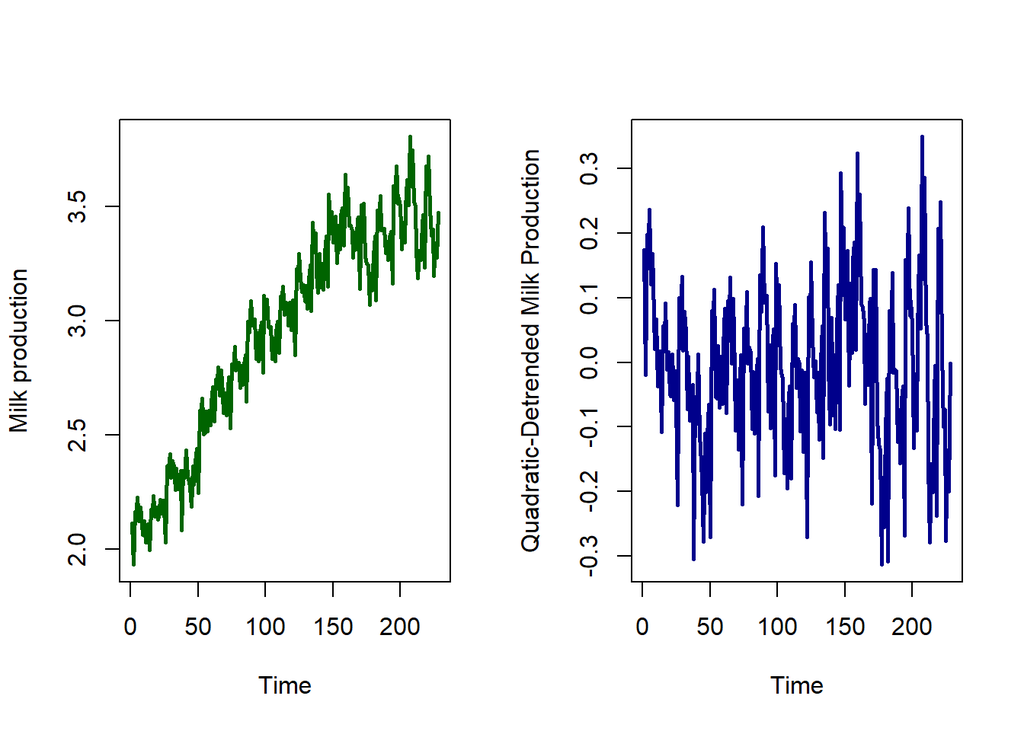

```r
par(mfrow=c(1,2))
plot(x = Trend,
     y = Milk,
     type = "l",
     ylab = "Milk production",
     xlab = "Time",
     col = "darkgreen",
     lwd = 2.5)
plot(x = Trend,
     y = Detrend_Q_Milk,
     type = "l",
     ylab = "Quadratic-Detrended Milk Production",
     xlab = "Time",
     col = "darkblue",lwd = 2.5)
```

I am able to observe that the detrended quadratic milk production is able to reduce the linear growth effect of the original milk production by showing a more stable trend over time, which is not the case for the original milk production. In the original variable we can see that there is a positive trend between milk production and time, however it does not allow to see if there are other trends that are affecting the milk production. In this case, the detrended variable eliminates the effect of time in the milk production which shows a more random fluctuation that could be caused by the effect of other pattern that are not related to time.

4. Explain the meaning of the quadratic trend. What happens to the variable over time when the trend is quadratic?

The quadratic trend helps to determine whether a variable’s change over time is simply linear or if it’s influenced by additional factors that cause the rate of change to accelerate or slow down. This trend could show the presence of influences other than the passage of time are impacting the variable.

## Problem 3

Impact of September 11 in Air Travel in the United States: The Research and Innovative Technology Administration’s Bureau of Transportation statistics (BTS) conducted a study to evaluate the impact of the September 11, 2001, terrorst attach on U.S. Transportation. The study report and data can be found at https://www.bts.gov/archive/publications/estimated_impacts_of_9_11_on_us_travel/index. The goal of the study was stated as follows:

The purpose of this study is to provide a greater understanding of the passenger travel patterns of persons making long distance trips before and after September 11. The report analyzes monthly passenger movement data between January 1990 and April 2004. Data on three monthly time series are given in teh file Sep11Travel.csv for this period: (1) actual airline revenue passenger miles (Air RPM (000s)), (2) Rail passenger miles (Rail PM), and (3) Vehicle miles travelled (VMT (billions)).

In order to assess the impact of September 11, BTS took the following approach: Using data before September 11, it forecasted future data (under the assumption of no terrorist attack). Then, BTS compared the forecasted series with the actual data to assess the impact of the event.

1. Is the goal of this study descriptive or predictive?

I think this study mainly does a descriptive analysis since it is evaluating past data in the context of the Sep 11th attack(pre v.s post). Although there is a component of predictive analysis, evident in the forecasting of data based on pre-attack trends for comparison with post-attack data, the intention remains descriptive. The predictive aspect serves to provide a benchmark for understanding the deviation in trends caused by the event. So in short, the study’s goal is mainly descriptive.

2. What is the forecast horizon to consider in this task? Are next-month forecasts sufficient?

The forecast horizon should extend more than only a next-month analysis, since this short-term forecast isn’t enough for comprehensively understanding the long-term effects of the September 11th attacks on transportation. It’s important to consider a longer period, from several months to even years after the event. This timeframe will allow for an analysis that can help to identify the emerging patterns and trends resulting from the attack’s impact. Additionally, the forecast horizon for evaluation should match the length of the post-attack data utilized in the analysis since this will ensure a balanced examination of the changes in transportation patterns both before and after September 11th.

3. What level of automation does this forecasting task require? Consider the four questions related to automation.

The level of automation needed is low or not necessary at all, since the forecast needed is only a one time event and does not need to be repeated. Plus, Sep 11th attach is only a one time effect, which doe not need to be forecasted again.

1. How many series need to be forecasted? In this case, only three time series are needed for forecasting, so the task is not very complex.
2. Is the forecasting an ongoing process or a one time event? It would only be a one-time event since the data available is only for a limited period,so no ongoing forecast is needed.
3. Which data and software will be available during the forecasting period? The data needed is already in teh csv file provided in which the data provided already has a fixed timeframe. The software needed is Rstudio.
4. What forecasting expertise will be available at the organization during the forecasting period? The forecasting expertise needed for this project is low since the data provided is already distributed in a monthly format, and producing the forecast will not take too much work- plus its only a one time analysis, and not automated analysis is needed.

## Problem 4

Problem 2 The file DepartmentStoreSales.xls contains data on the quarterly sales for a department store over a 6-year period.

1. Create a well-formatted plot of the data.

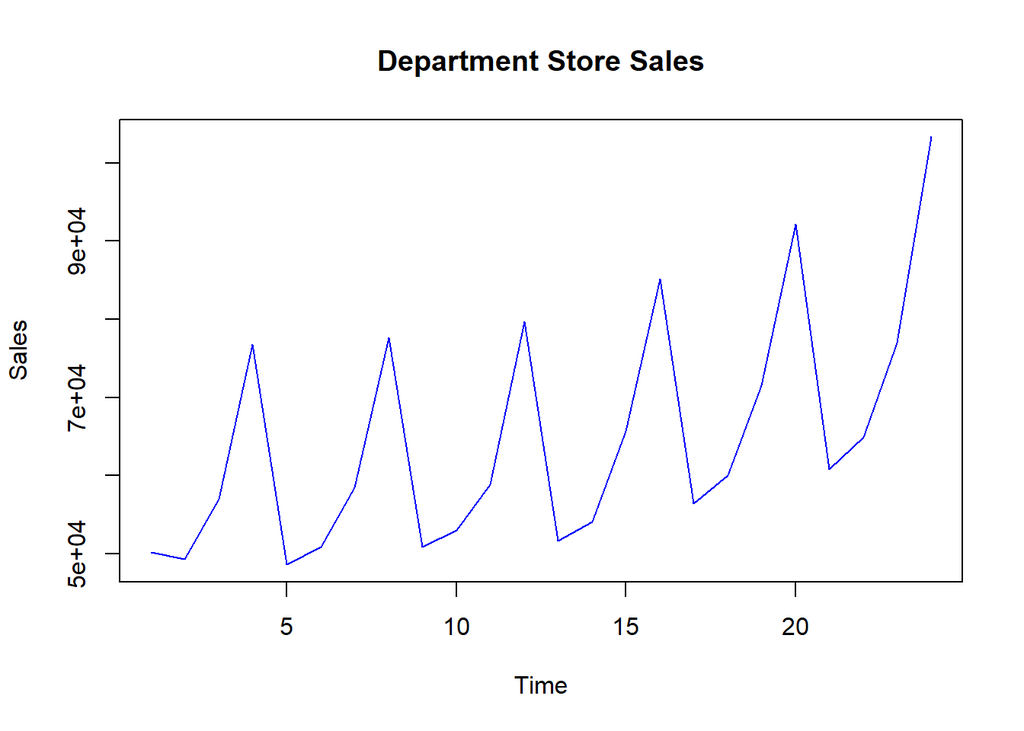

```r
DepartmentStoreSales<-read.csv("C:/Users/samal/Downloads/DepartmentStoreSales.csv", header=TRUE)
plot(x= DepartmentStoreSales$Quarter,
     y=DepartmentStoreSales$Sales,
     type="l",
     col="blue",
     xlab="Time",
     ylab="Sales",
     main="Department Store Sales")
```

2. Which of the four components (level, trend, seasonality, noise) seem to be present in the series?

It is clear that there is a seasonality since it we can see that there is always an spike in the 4th quarter of each year. There is also a trend since the data is increasing over time.

Problem 5

Souvenir sales: The file SouvenirSales.xls contains monthly sales for a souvenir shop at a beach resport town in Queensland, Australia, between 1995 and 2001. Back in 2001, the store wanted to use the data to forecast sales for the next 12 months (year 2002). they hired an analyst to generate forecasts. The analyst first partitioned the data into training and validation periods, with the validation period containing the last 12 months of data (year 2001). She then fit a regression model to sales, using the training period.

1. Create a well-formatted time plot of the data.

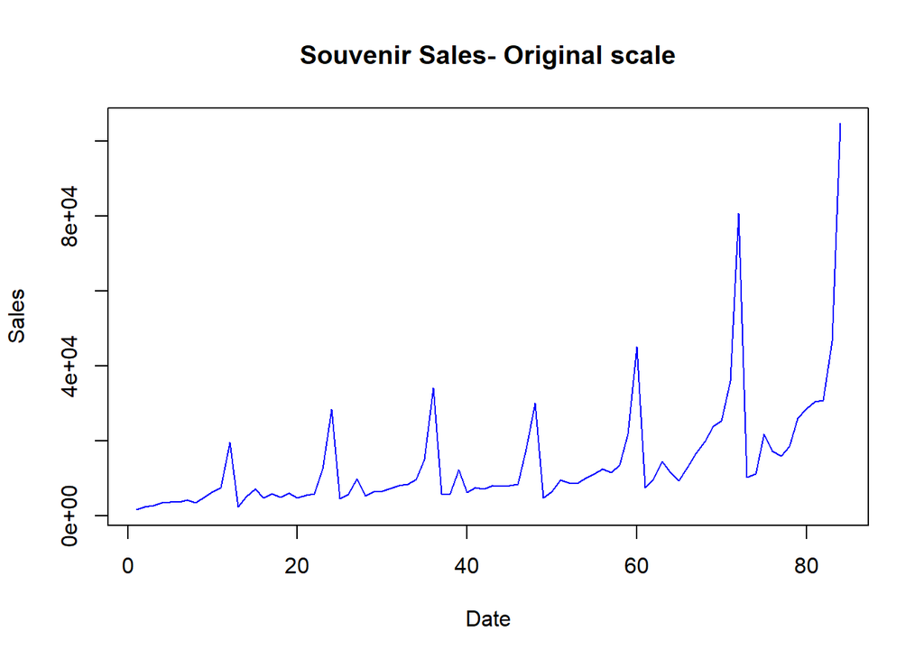

```r
souvenir_sales <- read.csv("C:/Users/samal/Downloads/SouvenirSales.csv", header=TRUE)
souvenir_sales$month_count <- seq(from = 1, to = nrow(souvenir_sales), by = 1)

plot(x= souvenir_sales$month_count,
     y=souvenir_sales$Sales,
     type="l",
     col="blue",
     xlab="Date",
     ylab="Sales",
     main="Souvenir Sales- Original scale")
```

2. Change the scale of the x axis, y axis, or both to logarithmic scale in order to achieve a linear relationship. Select the time plot that seems most linear.

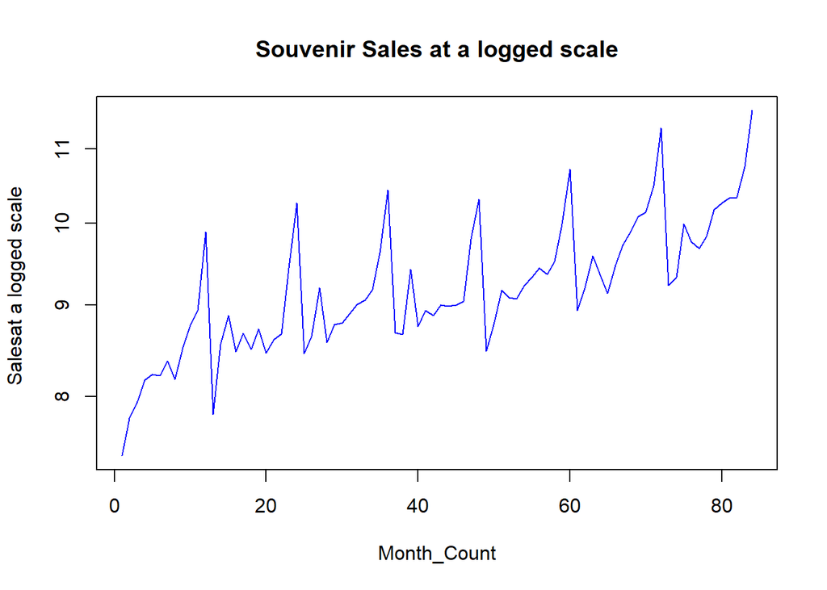

```r
plot(x= souvenir_sales$month_count,
     y=log(souvenir_sales$Sales),
     type="l",
     col="blue",
     xlab="Month_Count",
     ylab="Salesat a logged scale ",
     main="Souvenir Sales at a logged scale",
     log="y")
```

3. Comparing the two time plots, what can be said about the type of trend in the data? First, both graphs show a seasonal pattern, with a spike in sales and a consecutive drop. Second, the graph with sales at a original scale shows a nonlinear growth since some of the spikes are even lower than the previous spikes. Third, the second graph with sales at a logged scale shows a linear growth since the spikes increase linearly over time. Fourth, using the log scale allows to stabilize the variance of the sales spikes, which helps to see that sales is actually growing linearly over time.